# 001687_wanglab_figure2_distance_tuning_figure2_distance_tuning_ipynb

## Installing requirements

The cell below installs every Python package needed to run this notebook, at fully pinned versions, using [`uv`](https://github.com/astral-sh/uv) for fast resolution. In Colab the cell is collapsed by default — click the ▶ button to run it.

```python
# install cell skipped during CI (deps preinstalled into system Python)
```

> **⚠️ Restart runtime after install**

> The install may upgrade packages already loaded in the kernel. Go to **Runtime → Restart session**, then **Run all cells below** (skip this install cell on re-run).

# Figure 2: peri-head distance coding in the mouse brainstem

This notebook reproduces the Figure 2 panels of Xiao, Severson, et al. (2026), *Peri-Head Distance Coding in the Mouse Brainstem*, directly from [Dandiset 001687](https://dandiarchive.org/dandiset/001687), streaming the data rather than downloading it.

For each of six example PrV units it draws three panels:

| Panel | Content |
| --- | --- |
| **A. Raster** | Spike times aligned to wall-pass onset, one row per trial, grouped and coloured by wall distance |
| **B. PETH** | Peri-event time histogram, one trace per wall distance, mean +/- SEM across trials |
| **C. Tuning curve** | The stored z-scored firing rate versus wall distance from `processing/wall_tuning` |

**The experiment.** A head-fixed mouse sits while a motorised wall approaches and passes its head at a controlled distance. Second-order trigeminal (PrV) neurons respond to whiskers touching the wall, and report how far away that wall is. Two coding schemes appear in the data: *proximity* units that increase firing monotonically as the wall nears, and *map* units tuned to a preferred distance.

**Citation.**  
Xiao, Severson, et al. (2026). Peri-head distance coding in the mouse brainstem, https://doi.org/10.1016/j.neuron.2026.05.027.  
Dandiset 001687. https://doi.org/10.48324/dandi.001687/0.260805.1529.

## 1. What we stream, and why

The Dandiset holds two files per recording session:

- a **processed** file (no modality suffix) with sorted spike times, trials, tuning curves and PSTHs. These are small, a few MB each.
- a **raw** file (`_ecephys+image`) with the 30 kHz broadband, LFP, TTLs and a reference to the behaviour video. These are multi-GB.

This notebook only needs the processed files. It reads six of them, one per example unit, and never downloads a whole file: `remfile` fetches only the byte ranges that `h5py` actually asks for.

We pin the **published version** `0.260805.1529` rather than `draft`, so the figure is reproducible even if the Dandiset is later revised.

```python
import warnings

import h5py
import matplotlib.pyplot as plt
import numpy as np
import pandas as pd
import remfile
from dandi.dandiapi import DandiAPIClient
from matplotlib.colors import Normalize
from pynwb import NWBHDF5IO

warnings.filterwarnings("ignore", message=".*namespace.*already exists.*")

DANDISET_ID = "001687"
DANDISET_VERSION = "0.260805.1529"  # published snapshot; use "draft" for the latest
```

## 2. The six example units

Each row below identifies one Figure 2 unit by its DANDI asset path and its 0-based row in that file's `units` table. This mapping is also distributed as `figure_unit_manifest.csv` in the [manuscript repository](https://github.com/wanglab-neuro/2026_Xiao-Severson_Peri-head-distance), reproduced inline here so the notebook stands alone.

`tuning_type` is the classification carried in the NWB `units` table itself.

```python
FIGURE2_UNITS = pd.DataFrame(
    [
        # display, asset path,                                                      unit row, label,                          tuning
        ("Unit 1", "sub-Ephys2/sub-Ephys2_ses-20230208-sp-session-1.nwb",     4,  "20230208_sp_session_1_unit_5",  "proximity"),
        ("Unit 2", "sub-Ephys40/sub-Ephys40_ses-20230626-sp-session-1.nwb",   7,  "20230626_sp_session_1_unit_8",  "map"),
        ("Unit 3", "sub-Ephys88/sub-Ephys88_ses-20240905-sp-session-1.nwb",   3,  "20240905_sp_session_1_unit_4",  "map"),
        ("Unit 4", "sub-Ephys81/sub-Ephys81_ses-20240703-sp-session-1.nwb",   9,  "20240703_sp_session_1_unit_10", "map"),
        ("Unit 5", "sub-Ephys22/sub-Ephys22_ses-20221212-sp-session-2.nwb",  17,  "20221212_sp_session_2_unit_18", "map"),
        ("Unit 6", "sub-Ephys106/sub-Ephys106_ses-20240924-sp-session-1.nwb", 6,  "20240924_sp_session_1_unit_7",  "suppressed"),
    ],
    columns=["display_unit", "asset_path", "unit_index", "unit_label", "tuning_type"],
)
FIGURE2_UNITS
```

|  | display_unit | asset_path | unit_index | unit_label | tuning_type |
| --- | --- | --- | --- | --- | --- |
| 0 | Unit 1 | sub-Ephys2/sub-Ephys2_ses-20230208-sp-session-... | 4 | 20230208_sp_session_1_unit_5 | proximity |
| 1 | Unit 2 | sub-Ephys40/sub-Ephys40_ses-20230626-sp-sessio... | 7 | 20230626_sp_session_1_unit_8 | map |
| 2 | Unit 3 | sub-Ephys88/sub-Ephys88_ses-20240905-sp-sessio... | 3 | 20240905_sp_session_1_unit_4 | map |
| 3 | Unit 4 | sub-Ephys81/sub-Ephys81_ses-20240703-sp-sessio... | 9 | 20240703_sp_session_1_unit_10 | map |
| 4 | Unit 5 | sub-Ephys22/sub-Ephys22_ses-20221212-sp-sessio... | 17 | 20221212_sp_session_2_unit_18 | map |
| 5 | Unit 6 | sub-Ephys106/sub-Ephys106_ses-20240924-sp-sess... | 6 | 20240924_sp_session_1_unit_7 | suppressed |

## 3. Stream each session

`load_session` opens one asset over HTTP and pulls out the three things the figure needs: the trials table, the units table, and the stored tuning curves.

```python
def load_session(dandiset, asset_path):
    """Stream one NWB file and return (trials, units, tuning, distance_axis)."""
    asset = dandiset.get_asset_by_path(asset_path)
    url = asset.get_content_url(follow_redirects=1, strip_query=True)

    store = remfile.File(url)
    with h5py.File(store, "r") as h5, NWBHDF5IO(file=h5, load_namespaces=True) as io:
        nwb = io.read()
        trials = nwb.trials.to_dataframe()
        units = nwb.units.to_dataframe()

        tuning = None
        distances = None
        if "wall_tuning" in nwb.processing:
            module = nwb.processing["wall_tuning"]
            if "tuning_curves" in module.data_interfaces:
                tuning = module["tuning_curves"].to_dataframe()
            if "distance_axis" in module.data_interfaces:
                distances = module["distance_axis"].to_dataframe()["distance_mm"].to_numpy(float)

        return {
            "session_id": nwb.session_id or nwb.identifier,
            "trials": trials,
            "units": units,
            "tuning": tuning,
            "distances": distances,
        }


sessions = {}
with DandiAPIClient() as client:
    dandiset = client.get_dandiset(DANDISET_ID, DANDISET_VERSION)
    for asset_path in FIGURE2_UNITS["asset_path"].unique():
        sessions[asset_path] = load_session(dandiset, asset_path)
        info = sessions[asset_path]
        print(f"{info['session_id']:26s} {len(info['trials']):3d} trials  {len(info['units']):3d} units")
```

```
20230208_sp_session_1      200 trials   30 units
```

```
20230626_sp_session_1      200 trials   27 units
```

```
20240905_sp_session_1      200 trials   14 units
```

```
20240703_sp_session_1      200 trials   21 units
```

```
20221212_sp_session_2      255 trials   27 units
```

```
20240924_sp_session_1      200 trials   14 units
```

```python
example = sessions[FIGURE2_UNITS.loc[0, "asset_path"]]
print("trials columns :", list(example["trials"].columns))
print("distance axis  :", np.round(example["distances"], 2))
example["trials"].head()
```

[output not shown]

| id | start_time | stop_time | wall_distance_mm | trial_condition |
| --- | --- | --- | --- | --- |
| 0 | 40.755267 | 51.755267 | 10.742 |  |
| 1 | 55.474000 | 66.474000 | 22.742 |  |
| 2 | 69.976367 | 80.976367 | 24.742 |  |
| 3 | 84.794467 | 95.794467 | 14.742 |  |
| 4 | 99.580367 | 110.580367 | 18.742 |  |

## 4. Plotting helpers

Rasters and PETHs are computed here from the raw spike times rather than read from the stored PSTHs, so you can see exactly how they are built and change the window or binning. The tuning curves in panel C are the stored values.

Colour encodes wall distance throughout, near (red) to far (blue).

```python
WINDOW = (0.0, 12.0)      # seconds relative to wall-pass onset
BIN_WIDTH = 0.2           # PETH bin, seconds
SMOOTH_BINS = 3           # boxcar smoothing width, in bins
TUNING_SCALE = 2.0        # matches the manuscript figure
PETH_TICK_STEPS = [10, 10, 20, 10, 2, 10]   # y-axis step per row


def distance_colors(distances):
    cmap = plt.get_cmap("turbo_r")
    norm = Normalize(vmin=float(np.nanmin(distances)), vmax=float(np.nanmax(distances)))
    return {float(d): cmap(norm(float(d))) for d in distances}


def smooth(values, width):
    if width <= 1:
        return values
    return np.convolve(values, np.ones(width) / width, mode="same")


def spikes_in_trial(spike_times, start_time, window):
    """Spike times relative to trial onset, using binary search on sorted times."""
    lo = np.searchsorted(spike_times, start_time + window[0], side="left")
    hi = np.searchsorted(spike_times, start_time + window[1], side="right")
    return spike_times[lo:hi] - start_time


def trials_at_distance(trials, distance):
    return trials[np.isclose(trials["wall_distance_mm"].to_numpy(float), distance)]
```

```python
def plot_raster(ax, spike_times, trials, distances, colors, window):
    y = 0
    for distance in distances:
        for _, trial in trials_at_distance(trials, distance).iterrows():
            rel = spikes_in_trial(spike_times, float(trial["start_time"]), window)
            if rel.size:
                ax.vlines(rel, y + 0.08, y + 0.92,
                          color=colors[float(distance)], linewidth=0.25, alpha=0.85)
            y += 1
    ax.axvspan(3.0, 11.0, color="0.88", zorder=-10)   # wall in motion
    ax.set_xlim(window)
    ax.set_ylim(-1, max(y, 1))
    ax.set_yticks([])
    ax.tick_params(labelsize=8, length=2)
    for side in ("top", "right"):
        ax.spines[side].set_visible(False)


def plot_peth(ax, spike_times, trials, distances, colors, window, bin_width, smooth_bins):
    edges = np.arange(window[0], window[1] + bin_width, bin_width)
    centers = edges[:-1] + bin_width / 2
    for distance in distances:
        rows = trials_at_distance(trials, distance)
        if rows.empty:
            continue
        rates = np.asarray(
            [np.histogram(spikes_in_trial(spike_times, float(t["start_time"]), window),
                          bins=edges)[0] / bin_width for _, t in rows.iterrows()],
            dtype=float,
        )
        mean = smooth(np.nanmean(rates, axis=0), smooth_bins)
        sem = smooth(np.nanstd(rates, axis=0, ddof=1) / np.sqrt(max(len(rates), 1)), smooth_bins)
        color = colors[float(distance)]
        ax.plot(centers, mean, color=color, linewidth=1.1)
        ax.fill_between(centers, mean - sem, mean + sem, color=color, alpha=0.15, linewidth=0)
    ax.axvspan(3.0, 11.0, color="0.88", zorder=-10)
    ax.set_xlim(window)
    ax.set_ylabel("sp/s", fontsize=8)
    ax.tick_params(labelsize=8, length=2)
    for side in ("top", "right"):
        ax.spines[side].set_visible(False)


def plot_tuning(ax, session, unit_index, colors, scale):
    tuning, distances = session["tuning"], session["distances"]
    if tuning is None or distances is None:
        ax.text(0.5, 0.5, "no tuning", ha="center", va="center",
                transform=ax.transAxes, fontsize=8)
        ax.set_axis_off()
        return

    unit_label = str(session["units"].iloc[unit_index].get("unit_label", ""))
    match = tuning[tuning["unit_label"].astype(str) == unit_label] if "unit_label" in tuning else tuning.iloc[0:0]
    row = match.iloc[0] if not match.empty else tuning.iloc[unit_index]

    y = np.asarray(row["zfr_mean"], dtype=float) * scale
    yerr = np.asarray(row["zfr_sem"], dtype=float) * scale if "zfr_sem" in row else np.full_like(y, np.nan)
    x = distances[: len(y)]

    ax.plot(x, y, color="black", linewidth=0.8, zorder=1)
    for xi, yi, ei in zip(x, y, yerr):
        color = colors.get(float(xi), "black")
        ax.errorbar(xi, yi, yerr=None if np.isnan(ei) else ei, fmt="o",
                    color=color, ecolor=color, elinewidth=0.7, capsize=0,
                    markersize=3.5, zorder=2)
    ax.set_xlabel("Wall distance (mm)", fontsize=8)
    ax.set_ylabel("Firing rate (z-score)", fontsize=8)
    ticks = x[np.linspace(0, len(x) - 1, min(5, len(x)), dtype=int)]
    ax.set_xticks(ticks)
    ax.set_xticklabels([f"{v:.0f}" for v in ticks])
    ax.tick_params(labelsize=8, length=2)
    for side in ("top", "right"):
        ax.spines[side].set_visible(False)
```

## 5. Build the figure

One row per unit, ordered as in the manuscript. The shaded band marks the interval during which the wall is in motion past the animal's head.

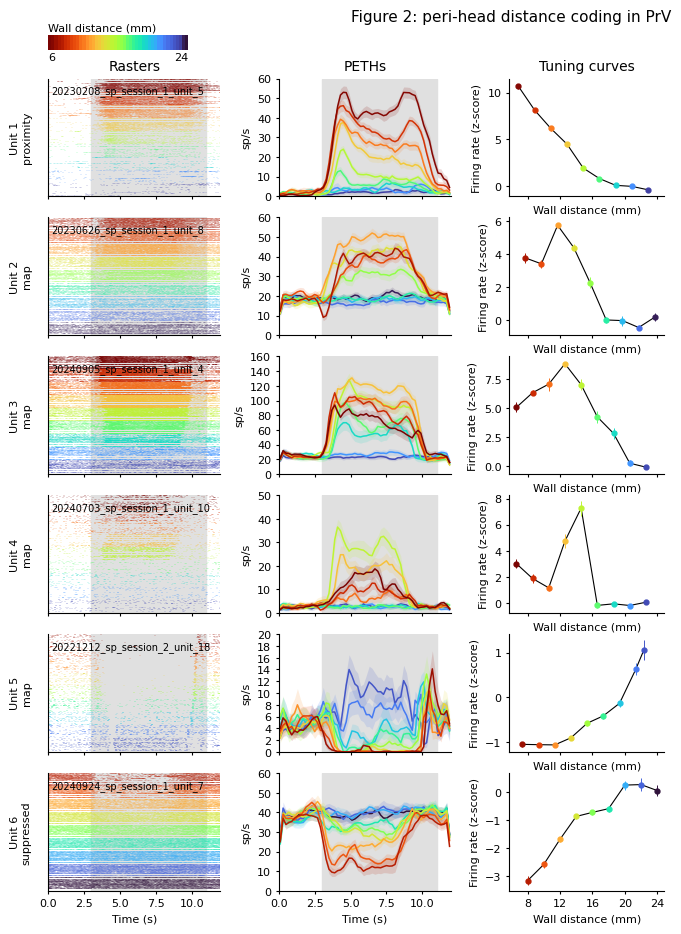

```python
def add_distance_legend(fig, distances, colors):
    ordered = np.array(sorted(distances), dtype=float)
    left, bottom, width, height = 0.10, 0.945, 0.20, 0.016
    ax = fig.add_axes([left, bottom, width, height])
    for i, distance in enumerate(ordered):
        ax.bar(i, 1, color=colors[float(distance)], width=1.0, align="edge")
    ax.set_xlim(0, len(ordered))
    ax.set_ylim(0, 1)
    ax.set_axis_off()
    fig.text(left, bottom + 0.020, "Wall distance (mm)", fontsize=8, ha="left")
    fig.text(left, bottom - 0.011, f"{ordered[0]:.0f}", fontsize=8, ha="left")
    fig.text(left + width, bottom - 0.011, f"{ordered[-1]:.0f}", fontsize=8, ha="right")


# Distances are shared across sessions; order far-to-near to match the manuscript.
all_distances = sorted({float(d) for s in sessions.values() for d in s["distances"]})
distances_desc = np.array(all_distances)[::-1]
colors = distance_colors(np.array(all_distances))

n_rows = len(FIGURE2_UNITS)
fig, axes = plt.subplots(
    n_rows, 3,
    figsize=(7.0, max(2.2, 1.45 * n_rows + 0.8)),
    sharex="col",
    gridspec_kw={"width_ratios": [1.0, 1.0, 0.9], "wspace": 0.35, "hspace": 0.18},
)

for row_idx, unit in FIGURE2_UNITS.iterrows():
    session = sessions[unit["asset_path"]]
    spike_times = np.asarray(session["units"].iloc[unit["unit_index"]]["spike_times"], dtype=float)
    row_distances = np.array(sorted(session["distances"]))[::-1]

    plot_raster(axes[row_idx, 0], spike_times, session["trials"], row_distances, colors, WINDOW)
    plot_peth(axes[row_idx, 1], spike_times, session["trials"], row_distances, colors,
              WINDOW, BIN_WIDTH, SMOOTH_BINS)

    step = PETH_TICK_STEPS[row_idx] if row_idx < len(PETH_TICK_STEPS) else 10
    upper = max(step, float(np.ceil(axes[row_idx, 1].get_ylim()[1] / step) * step))
    axes[row_idx, 1].set_ylim(0, upper)
    axes[row_idx, 1].set_yticks(np.arange(0, upper + step * 0.5, step))

    plot_tuning(axes[row_idx, 2], session, unit["unit_index"], colors, TUNING_SCALE)

    axes[row_idx, 0].set_ylabel(f"{unit['display_unit']}\n{unit['tuning_type']}",
                                fontsize=8, rotation=90, labelpad=12)
    axes[row_idx, 0].text(0.02, 0.94, unit["unit_label"],
                          transform=axes[row_idx, 0].transAxes,
                          fontsize=7, va="top", ha="left")

axes[0, 0].set_title("Rasters", fontsize=10)
axes[0, 1].set_title("PETHs", fontsize=10)
axes[0, 2].set_title("Tuning curves", fontsize=10)
axes[-1, 0].set_xlabel("Time (s)", fontsize=8)
axes[-1, 1].set_xlabel("Time (s)", fontsize=8)
fig.suptitle("Figure 2: peri-head distance coding in PrV", fontsize=11, x=0.99, y=0.988, ha="right")
add_distance_legend(fig, distances_desc, colors)
fig.subplots_adjust(top=0.915, left=0.10, right=0.98, bottom=0.06)
plt.show()
```

## 6. Reading the figure

Together these illustrate the paper's claim that PrV carries not one but two distance codes, a monotonic proximity signal and a distributed map.

## 7. Going further

- **Other units.** Every session's `units` table carries `tuning_type`, `wall_responsive`, `pref_dist_mm` and `trial_include`, so you can select units by classification instead of using the fixed list above.
- **All sessions.** `client.get_dandiset(...).get_assets()` lists all 191 assets. The processed files are the ones without a modality suffix.
- **Raw data.** The `_ecephys+image` assets hold the 30 kHz broadband, the 1 kHz LFP, the digital TTL record, and an `ImageSeries` pointing at the behaviour video, if you want to work from the unprocessed signals.